# Statistical inference using weights and survey design

Pierre Walthéry

UK Data Service

October 2025

# Introductions

## Plan of the day

**11.15-12.00** Session 1: Survey Design: a refresher

*Coffee break*

**12.15-13.00** Session 2: Inference in theory and practice

*Lunch break*

**13.45-14.30** Session 3: R and Stata examples (1)

*Coffee break*

**14.45-15.30** Session 4: R and Stata examples (2)

# About the UK Data Service

## The UK Data Service in a nutshell

- Main repository of UK secondary social science data
- A provider of support, training and guidance
- Freely accessible, funded by the ESRC
- Who are we for?
  - Academic researchers and students
  - Government analysts
  - Charities and the voluntary sector
  - Business consultants
  - Independent research centres / think tanks

## Data curated

- Surveys:
  - Large-scale cross-sectional UK government surveys
  - Major UK longitudinal surveys
  - Multinational aggregate databases and survey data
- Census data – modern and historic records
- Business and administrative microdata
- Deposited survey data and multimedia/qualitative data sources

## User support and training

- Helpdesk for data-related queries
- Webinars and online workshops:
  - datasets, methods, and software focused
- Online learning materials: Data Skills Modules and pathways
- ‘Traditional’ survey-related and new forms of data ie computational social science.
- Supporting data literacy among undergraduate students

## What this workshop is…

- Second of a series of introductory workshops on using weights and survey design information to compute accurate estimates
- Practical, everyday user-oriented
- Plain English
- New approach: community of practice

## And isn’t

- A comprehensive course on complex survey design/statistical inference
- An introduction to R or Stata
- An introduction to advanced topic of statistical inference
- Some basic degree of familiairyt with the topic is assumed

# 1. Survey design and statistical inference - a refresher

# Basics of Survey Design

## Samples and sampling

- Survey design: strategies used to collect samples.
- Sample members can either be selected:
  - purposively, for example when internet users are self-selecting to take part in an online poll
  - randomly (all members of the target population have a non-zero chance of selection), AKA *probability sampling*.
- The process of deriving population estimates from a sample is called *inference*

## Probability samples and sampling

- *Random sampling* minimises the risk of obtaining unrepresentative samples and biased population estimates:
  - ie when certain groups are under represented or excluded.
- *Simple random sampling* - directly drawing members of the target population - is considered the best way to conduct RS and avoid bias…
- … But difficult to achieve: need a list of the population (national register).
- … Not necessarily optimal:
  - when some groups have different probabilities of taking part in surveys than others
  - when smaller groups need to be over-represented to obtain more reliable and precise statistics.
  - costly in low population density areas

## The survey design problem

- Designing surveys entails striking a balance between:
  - representativeness and precision (ie sample size)…
  - while keeping costs down (surveys are expensive!).
- Large scale social surveys tend to rely on other techniques seen as better at striking this balance than SRS
  - To ensure correct representation of each country of the UK (ie by drawing separate samples for each one of them).
  - To improve the precision of estimates estimates for certain groups, for example ethnic minorities, and these need adequate sample size.
- In that sense SRS is more of a theoretical possibility than a real world type of social surveys
  - *Complex sample design* covers everything else - perhaps not the best label

## Common ‘complex’ sampling techniques

- **Clustering** comes together with *multistage sampling*: that is drawing sample units in several steps rather than all at once.

  Consists of dividing the population into groups *as internally heterogeneous as possible* - ie ‘mini populations’, some of which are then randomly drawn while others are left out.
- **Stratifying** also consists in dividing the population into groups according to some characteristics, but this time, we will be drawing units from every one of them
- Adjusting sampling proportion

## The UK context

- No sampling frame ie national register of the population
- The closest to a sampling frame we have is the Postcode Address File from Royal Mail: a list of addresses
- For Northern Ireland the most commonly used is the Land and Property Services Agency’s (LPSA).
- We cannot use the PAF to directly draw samples of households or individuals, as their number at each address is not know.
- However, the address structure of the PAF easily enables geographical clustering of UK surveys. Addresses, or ’delivery points’ cluster into larger units

## Example

- The post code M13 9PL is embedded within the the M13 ‘postcode district’ and the M13 9 ‘postcode sector’.
- Survey designs often use either postcode sectors or districts as Primary Sampling Units (PSUs) to reduce fieldwork costs and time.

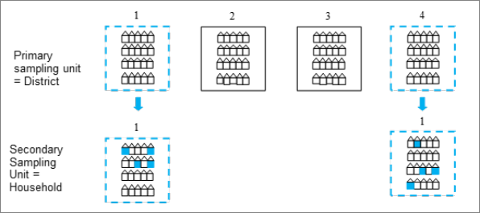

## Example

The previous figure illustrates clustering with four districts:

- The higher level clusters, i.e. those at which the first random draw happened, are the Primary Sampling Units (PSUs).
- Districts 1 and 4 have been selected to be in the sample.
- A second stage of sampling follows: addresses are sampled from within the two sampled districts
- Subsequent drawing of either:
  - further clusters, for example, households or
  - final individual sample members
- In large scale surveys the PSUs are often geographical areas.

## Household level clustering -1

- Arises in some large-scale household surveys in the UK such as the Labour Force Survey.
- Imagine estimating the proportion of individuals born abroad from a population of 100 people in 50 households.
- Those born abroad are more likely to live together ‘clustered’ within households, than be scattered randomly across all households.
- some households being wholly overseas born, some mixed and most wholly UK born.

e.g.

```
Household 1: 1 UK born individuals
Household 2: 3 UK born
Household 3: 2 Overseas born
Household 4: 6 UK born
Household 5: 1 Overseas born, 1 UK born
Household 6: 2 UK born
Household 7: 1 UK born
Household 8: 1 UK born
Household 9: 5 Overseas born
Household 10: 3 UK born
```

## Household level clustering - 2

And so on…

- Clustering within households means that if we select one in ten of the households for our sample we might expect the sample to be less accurate in predicting the proportion of our population who were born outside the UK than if we had sampled individuals at random.
- Clustering comes at the cost of making the sampling coarser - as we shrink the size of the population from which it is drawn - reducing its diversity - which in turn makes the estimates draw from it less precise.

## Stratification

- In stratified sampling, the population is divided into groups, or strata, and a sample of units is selected from *each* strata.
- Stratified sampling ensures that the sample includes a certain proportion of units from the selected groups that may have been missed otherwise.
- By contrast with clustering, strata are constructed so as to maximise their internal homogeneity
- It is considered that overall stratification increases the precision of survey estimates, by improving the representativeness of potentially less represented or harder to reach groups.

## An example of stratified sampling

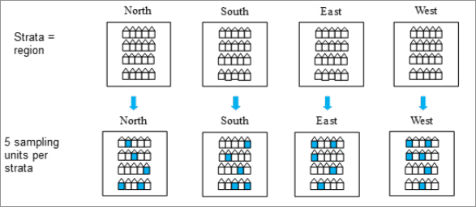

- The previous figure provides an example where the population is divided into four strata: North, South, East and West. Within each strata five sampling units (ie addresses) are selected.
- UK surveys are usually stratified:
  - geographically (e.g. Government Office Regions);
  - socio-economic characteristics (occupations)
  - or demography (e.g. proportion of people who are pensioners in areas).
- Such information is usually obtained from Census data.

## Sampling fraction

- In simple random sampling, each element drawn from the sampling frame has an equal selection probability.
- In stratified sampling, *proportionate stratification* is when the same sampling fraction is used accross all strata
- If we use *disproportionate stratification*, the sampling fraction varies across strata. This method is is useful when a group of interest is small, ie less populated areas or ethnic minority groups.
- Disproportionate stratification will mean some groups are over-represented in the sample and therefore adjustments are needed before we can analyse the data.

## One slide summary

- There is no such thing as a sampling frame - a list of all UK residents to pick from
- even if there were one, some people would be less likely to take part to survey than others.
- Most UK social surveys rely on multi-stage clustering and stratification, alongside sampling proportionate to size
- These strike a compromise between issues such as tackling non response, unequal probability of selection, improving the representativeness of hard to reach groups while keeping fieldwork costs down.

[figure not shown]

Practical inference using weights and survey design